# Biomantas e Geossintéticos Biodegradáveis

Bioengenharia de Solos

Prof. Dr. Luiz Diego Vidal Santos

## Abertura Visão Geral da Aula

Roteiro da aula Tópicos estruturantes

- 1 O que são biomantas?
- 2 Biomanta × Geotêxtil sintético
- 3 Tipos de biomantas e materiais
- 4 Propriedades mecânicas e normas
- 5 Projeto e dimensionamento
- 6 Instalação em campo
- 7 Monitoramento e biodegradação
- 8 Síntese e atividade

Objetivo central Proteção temporária e sucessão vegetal

Compreender os princípios de funcionamento das **biomantas** (*erosion control blankets*) como técnica de **proteção de superfície** contra a erosão laminar, diferenciar biomantas de **geotêxteis sintéticos**, dominar os critérios de **seleção**, **dimensionamento** e **instalação** para garantir a **sucessão vegetal** sob a manta.

ECBs · ABNT NBR 16.757:2020 Coco · Sisal · Juta · Palha Biodegradação e MO

# O que são biomantas?

## Conceito Definição e mecanismo de proteção superficial

Erosion Control Blankets (ECBs) Tramas biodegradáveis de fibras naturais

- **Protegem** contra impacto direto das gotas de chuva (*splash erosion*)
- **Reduzem** a velocidade do escoamento superficial
- **Retêm** umidade e sementes, criando microclima favorável
- **Degradam-se** progressivamente, incorporando matéria orgânica

A biomanta é uma **proteção temporária** que cumpre sua função física até que a **vegetação se estabeleça** como cobertura permanente.

Sem biomanta Solo exposto

Chuva (energia cinética) $\rightarrow$ impacto direto no solo $\rightarrow$ desagregação de partículas $\rightarrow$ **erosão laminar**.

Com biomanta Solo protegido

Energia dissipada na trama $\rightarrow$ solo protegido $\rightarrow$ germinação sob a manta $\rightarrow$ **vegetação permanente**.

## Conceito Galeria: geotêxteis e biomantas em campo

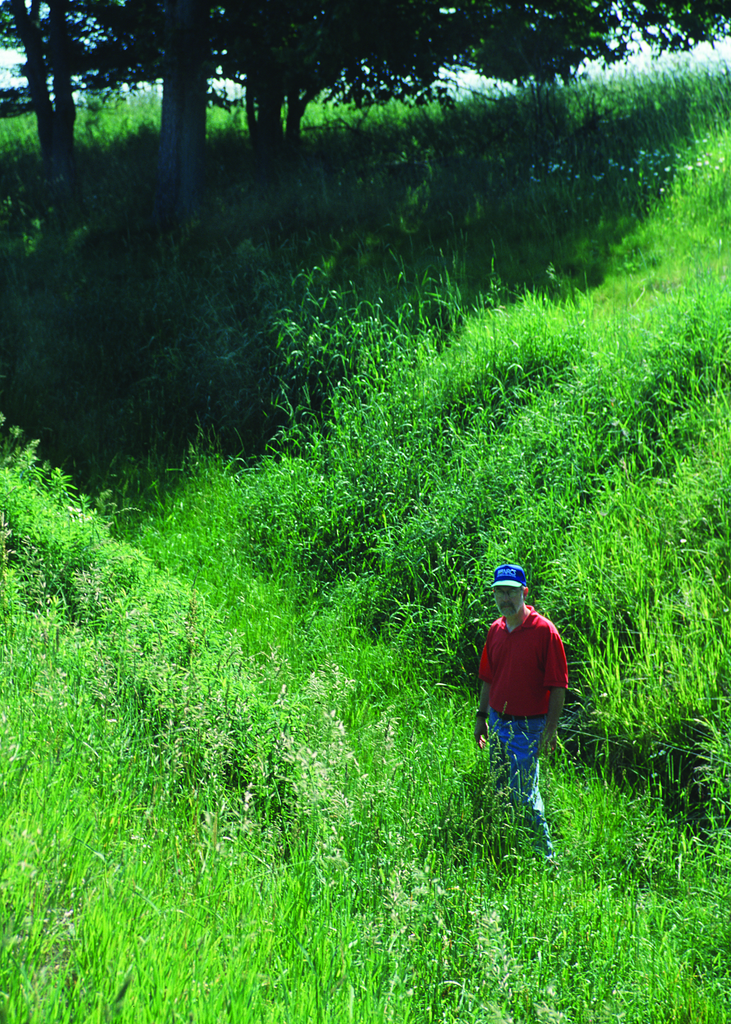

Geotêxtil instalado em canal de drenagem em Michigan, EUA

Canal de drenagem revestido (Michigan, EUA) Foto: Fred Gasper / USDA NRCS · Public Domain

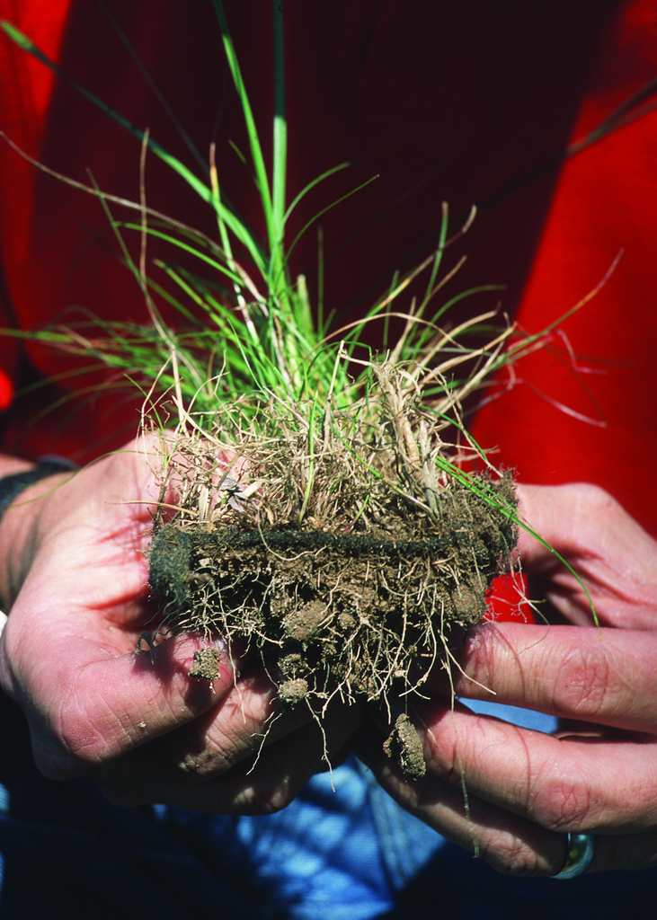

Detalhe de gramíneas crescendo através de geotêxtil em Michigan, EUA

Emergência de gramíneas através da malha Foto: Fred Gasper / USDA NRCS · Public Domain

## Conceito Evolução histórica, ganhos e marco brasileiro

**1950s–1960s:** primeiros geotêxteis sintéticos (polipropileno, poliéster).

**1970s–1980s:** biomantas de juta (Índia/Bangladesh) e introdução da fibra de coco de maior durabilidade.

**1990s–2000s+:** padronização ASTM/ECTC e biomantas pré-semeadas (*pre-seeded blankets*) regionalizadas.

| Critério | Sem proteção | Com biomanta |
| --- | --- | --- |
| Perda de solo | 20–80 t ha⁻¹ ano⁻¹ | 2–8 t ha⁻¹ ano⁻¹ |
| Germinação / Umidade | 30–50% · Baixa | 70–90% · Alta |
| Temp. do solo | Extrema | Moderada |

Normatização no Brasil ABNT NBR 16.757:2020

Regula biomantas para controle de erosão, exigidas em:

- Licenciamento de rodovias (DNIT)
- Recuperação de mineração (IBAMA/ANM)
- Planos de Recuperação de Áreas Degradadas (PRAD)
- Obras de drenagem urbana

A redução de perda de solo pode atingir **90–95%** com biomantas de fibra de coco bem instaladas (Lekha, 2004).

# Biomanta × Geotêxtil sintético

## Comparação Arquitetura e critérios de seleção técnica

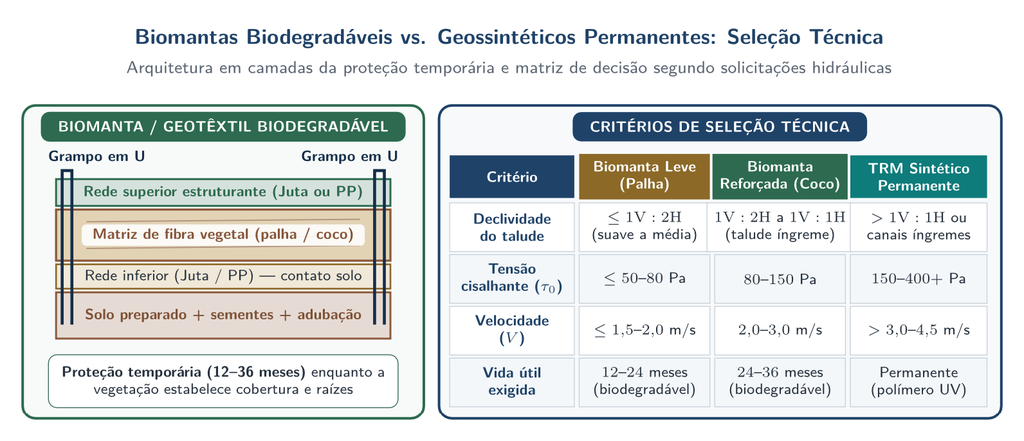

Arquitetura em camadas da biomanta e matriz de decisão técnica segundo declividade e tensão cisalhante

Biomantas biodegradáveis vs. geossintéticos permanentes Critérios hidráulicos e geotécnicos segundo declividade, tensão cisalhante (τ₀), velocidade (V) e vida útil

A seleção entre biomanta leve (palha), biomanta reforçada (coco) e TRM sintético permanente depende diretamente da declividade e da tensão cisalhante atuante ($\tau_0$).

## Comparação Biomanta (ECB) versus Geotêxtil sintético

Biomanta biodegradável (ECB) Função temporária · R$ 5–25 m⁻²

- **Material:** fibras naturais (coco, palha, juta, sisal)
- **Vida útil:** 6 meses a 5 anos · incorpora MO ao solo
- **Permeabilidade:** alta (infiltração e trocas gasosas)
- **Impacto ambiental:** baixo (material renovável)

Geotêxtil sintético Função permanente · R$ 8–40 m⁻²

- **Material:** polipropileno, poliéster ou nylon (não biodegradável)
- **Vida útil:** 20–50+ anos · filtração, separação e reforço estrutural
- **Subtipos:** tecido (com vegetação associada) ou não tecido (sem vegetação)

| Propriedade | Biomanta | Geotêxtil |
| --- | --- | --- |
| Proteção erosiva | ★★★★★ | ★★★☆☆ |
| Retenção umidade | ★★★★★ | ★★☆☆☆ |
| Resistência mecânica | ★★☆☆☆ | ★★★★★ |
| Sustentabilidade | ★★★★★ | ★★☆☆☆ |
| Custo-benefício | ★★★★☆ | ★★★☆☆ |

**Árvore de decisão:** função temporária com revegetação $\rightarrow$ **Biomanta** (coco, palha, juta, sisal). Função estrutural permanente $\rightarrow$ **Geotêxtil** (tecido se houver vegetação; não tecido se não houver).

# Tipos de biomantas e materiais

## Materiais Classificação por fibra vegetal

Excelente retenção hídrica e resistência microbiológica; ideal para taludes íngremes e margens fluviais.

Sisal (*Agave sisalana*) 2–4 anos · 120–180 kN m⁻¹

Boa retenção hídrica, fibra nacional (Nordeste brasileiro); taludes moderados a íngremes.

Juta (*Corchorus spp.*) 1–2 anos · 80–150 kN m⁻¹

Boa retenção e trabalhabilidade; indicada para uso geral e canais.

Palha de arroz / trigo 3–12 meses · 20–50 kN m⁻¹

Retenção moderada, baixo custo e alta disponibilidade; áreas planas e taludes suaves.

| Fibra | Durabilidade | Resistência | Custo |
| --- | --- | --- | --- |
| Coco | ★★★★★ | ★★★★☆ | ★★★☆☆ |
| Palha | ★★☆☆☆ | ★★☆☆☆ | ★★★★★ |
| Juta | ★★★☆☆ | ★★★☆☆ | ★★★★☆ |
| Sisal | ★★★★☆ | ★★★★☆ | ★★★☆☆ |

No **Nordeste do Brasil**, **coco** e **sisal** são prioritários pela oferta regional, menor frete e fortalecimento da cadeia produtiva local.

## Materiais Estrutura construtiva e biomantas pré-semeadas

Arquitetura sanduíche Componentes e fixação

- **Rede superior:** malha de contenção das fibras
- **Núcleo de fibras:** coco, palha, juta ou sisal
- **Rede inferior:** malha de suporte em contato com o solo
- **Grampos metálicos em “U”:** ancoragem direta ao terreno

| Tipo | Redes | Fibra | Gramatura |
| --- | --- | --- | --- |
| Simples | 1 rede PP | Palha | 300–400 g m⁻² |
| Dupla | 2 redes PP | Coco | 400–700 g m⁻² |
| Reforçada | 2 redes + fio aço | Coco+palha | 700–1.000 g m⁻² |

Biomantas com sementes (*pre-seeded*) Sementes incorporadas entre camadas

**Vantagens:** elimina etapa de semeadura, garante distribuição uniforme e proteção imediata.

**Limitações:** custo superior, seleção de espécies restrita ao fabricante e prazo de validade das sementes.

Pesquisas testam biomantas com **sementes nativas do Cerrado e Caatinga**, ampliando a restauração ecológica pré-semeada (Oliveira et al., 2021).

# Propriedades mecânicas e normas

## Normas Ensaios laboratoriais e referências normativas

| Ensaio laboratorial | Norma | Parâmetro |
| --- | --- | --- |
| Resistência à tração / Alongamento | ASTM D6818 | kN m⁻¹ / % |
| Gramatura | ASTM D6475 | g m⁻² |
| Espessura / Abertura de malha | ASTM D6525 / D6567 | mm |
| Degradação UV / Biodegradação | ASTM D4355 / ISO 17556 | % retenção / % massa |

| Propriedade típica (Coco) | Faixa |
| --- | --- |
| Gramatura / Espessura | 400–700 g m⁻² · 8–15 mm |
| Tração (MD) / Alongamento | 5–15 kN m⁻¹ · 15–40% |
| Abertura de malha | 10–20 mm |

Arcabouço normativo Normas brasileiras e internacionais

- **Brasil:** ABNT **NBR 16.757:2020** (Biomanta), ABNT **NBR 12.553** (Terminologia), **DNIT 071/2006 - ES**.
- **Internacionais:** **ASTM D6459** (desempenho de RECPs), **ECTC** e **EN 13252** (drenagem).

A classificação **ECTC** divide as biomantas de **Type A** (curta duração, $\le 12$ meses) a **Type D** (longa duração, $> 36$ meses).

# Projeto e dimensionamento

## Dimensionamento Critérios de seleção por declividade e cálculo de área

< 1V:3H (< 18°) Talude suave

Biomanta de **palha ou juta leve** (300–400 g m⁻²).

1V:3H–1V:2H (18°–27°) Moderado

Biomanta de **coco simples** (400–500 g m⁻²).

1V:2H–1V:1H (27°–45°) Íngreme

Biomanta de **coco dupla rede** (500–700 g m⁻²).

> 1V:1H (> 45°) Escarpado

| Fator de projeto | Influência na especificação |
| --- | --- |
| Declividade / Velocidade | Gramatura, rede e resistência ao arraste |
| Solo / Espécies | Abertura de malha para germinação |
| Pluviometria / Acesso | Durabilidade exigida e peso dos rolos |

**Quantidade total de biomanta ($Q_{biom}$):**

$$Q_{biom} = A_{talude} \times (1 + f_s)$$

Onde $A_{talude}$ = área do talude (m²) e $f_s$ = fator de sobreposição ($0,10\text{–}0,20$).

# Instalação em campo

## Instalação Procedimento construtivo e controle pós-instalação

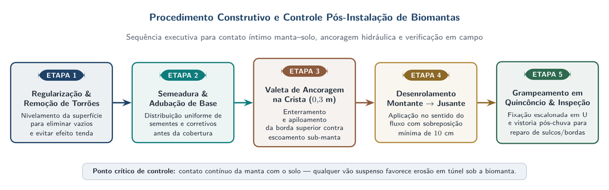

Fluxo executivo em cinco etapas para instalação de biomantas e controle de contato manta-solo

Procedimento construtivo e controle pós-instalação Regularização, semeadura, valeta de ancoragem (0,3 m), desenrolamento montante-jusante e grampeamento em quincôncio

**Ponto crítico de controle:** contato contínuo da manta com o solo — qualquer vão suspenso (“efeito tenda”) induz erosão em túnel sob a biomanta.

## Instalação Detalhamento executivo e erros comuns em obra

**01 · Preparo da superfície:** remover pedras/detritos, escarificar 2–3 cm e aplicar sementes/adubação.

**02 · Ancoragem superior:** abrir trincheira de 15–20 cm, enterrar 30 cm da borda superior e compactar.

**03 · Desenrolamento (cima $\rightarrow$ baixo):** garantir aderência sem bolsas de ar, sobreposição lateral $\ge 10\text{ cm}$ e longitudinal $\ge 15\text{ cm}$.

**04–05 · Grampeamento e pé:** grampos em “U” de aço (15–20 cm) a **1–2 grampos m⁻²** (reforçar bordas) e ancoragem na trincheira de pé.

| Erro de instalação | Consequência erosiva |
| --- | --- |
| Manta solta (bolsas de ar) | Erosão por baixo da manta |
| Sem trincheira superior | Água penetra sob a manta |
| Sobreposição insuficiente | Exposição do solo nas juntas |
| Poucos grampos | Deslocamento com chuva |
| Manta esticada demais | Rompe por contração/dilatação |

# Monitoramento e biodegradação

## Monitoramento Acompanhamento, transição e ações corretivas

| Período | Verificação | Meta |
| --- | --- | --- |
| 7 dias | Aderência e grampeamento | Sem deslocamento |
| 15 dias | Germinação sob a manta | > 40% visível |
| 30 dias | Cobertura vegetal | > 50% |
| 60 dias | Cobertura + integridade | > 70% cobertura |
| 90 dias | Início da biodegradação | Manta afrouxando |
| 180 dias | Biodegradação avançada | Vegetação dominante |
| 365 dias | Biodegradação completa* | Solo 100% vegetado |

| Problema observado | Ação corretiva |
| --- | --- |
| Manta levantada | Regrampear + compactar |
| Erosão sob a manta | Corrigir drenagem a montante |
| Germinação irregular | Semeadura complementar |
| Degradação prematura | Substituir trecho afetado |
| Fauna escavadora | Tela metálica complementar |

**Sucesso:** cobertura **> 80% em 90 dias**, sem erosão sub-manta; ao decompor-se, a manta incorpora **matéria orgânica** e húmus ao solo.

## Integração Monitorar proteção e recuperação do substrato

| Função | Indicador | Como comparar |
| --- | --- | --- |
| Proteção superficial | Cobertura, solo exposto e sulcos | Parcelas ou pontos fixos após chuvas |
| Retenção de material | Sedimento exportado e depositado | Área, período e chuva documentados |
| Condição física | Infiltração, agregação, densidade e RP | Mesmo método, profundidade e condição hídrica |
| Recuperação biológica | CBM, respiração, $qCO_2$ e enzimas | Protocolo e época comparáveis |

**Retomada da Aula 03 e da antiga Aula 12.1 de Análise Ambiental:** separe eficiência física da manta, estabelecimento vegetal e recuperação biológica, incluindo parcela controle ou referência sempre que possível.

# Síntese e atividade

## Síntese Pontos fundamentais e fluxo conceitual

Resumo técnico Seis conclusões centrais

1. **Biomantas** são tramas biodegradáveis de fibras naturais para proteção temporária
2. Diferem dos **geotêxteis sintéticos** por degradarem-se e favorecerem a revegetação
3. **Fibra de coco** é a mais durável; **palha** é a de menor custo
4. A escolha depende de **declividade**, **solo** e **durabilidade requerida**
5. Instalação **de cima para baixo** com trincheiras e grampos evita erosão sub-manta
6. A **biodegradação** agrega matéria orgânica ao solo restaurado

01 · Fibras Matéria-prima

Coco, palha, juta ou sisal em mantas de 300–1.000 g m⁻².

02 · Instalação Ancoragem

Trincheiras de crista/pé + grampos em “U” mantendo contato pleno.

03 · Sucessão Cobertura viva

Proteção contra impacto permite germinação e enraizamento.

04 · Solo Restauração

Biodegradação incorpora MO e consolida o solo estabilizado.

## Atividade Especificação técnica de biomanta em encosta urbana

Estudo dirigido · 30 min projeto + 10 min apresentação Encosta urbana · 200 m² · 30° · argiloso pH 5,5 · 800 mm ano⁻¹

Elaborem a especificação técnica completa para proteção urgente contra erosão laminar:

1. **Tipo de biomanta** (fibra, gramatura, nº de redes) e **mistura de sementes**
2. **Quantidade total** de biomanta (incluindo sobreposição) e **número de grampos**
3. **Esquema de instalação** (trincheiras, direção, sobreposições)
4. **Cronograma de monitoramento** para 1 ano
5. **Custo estimado** (biomanta + grampos + mão de obra)

| Critério de avaliação | Peso |
| --- | --- |
| Seleção da biomanta | 20% |
| Cálculo de quantidades | 20% |
| Esquema de instalação | 20% |
| Seleção de espécies | 15% |
| Cronograma de monitoramento | 15% |
| Estimativa de custo | 10% |

## Referências Referências bibliográficas

Normas e literatura técnica Base bibliográfica da aula

- ABNT (2020). *NBR 16.757:2020 - Geossintéticos - Biomanta para controle de erosão superficial*. Associação Brasileira de Normas Técnicas.
- ECTC (2014). *Erosion Control Technology Council - Standard Specification for RECPs*.
- Hälbich, F. B. (2014). Erosion control using hydromulch and biomantas. *Eng. Sanit. Ambien.*, 19(2), 155–163.
- Lekha, K. R. (2004). Field instrumentation and monitoring of soil erosion in coir geotextile stabilised slopes. *Geotextiles and Geomembranes*, 22(5), 399–413.
- Oliveira, R. A. et al. (2021). Biomantas com sementes nativas para restauração ecológica. *Rev. Bras. Eng. Agrícola Amb.*, 25(8), 567–574.
- Rickson, R. J. (2006). Controlling sediment at source: an evaluation of erosion control geotextiles. *Earth Surface Processes Landforms*, 31(5), 550–560.
- Subaida, E. A., Chandrakaran, S., & Sankar, N. (2008). Experimental investigation on tensile strength behavior of coir geotextiles. *Geomechanics and Geoengineering*, 3(1), 55–61.
- Vishnudas, S. et al. (2006). The protective and water-harvesting effect of biomantas installed on steep slopes. *Land Degrad. Dev.*, 17(1), 55–64.

Obrigado!

**Prof. Luiz Diego Vidal Santos**

📧 luiz.diego@uefs.br

🌐 ldvsantos.github.io/cv